# Final Report: iPhone or iGo (to the gym)

## Introduction

For *QAC 307*, I decided to focus on the impact of exercise on smartphone use. I realized that I am constantly on my phone and use it whenever I am bored or nervous. I also independently hypothesized that exercise reduces general boredness/nervousness. Through the synthesis of these two concepts, I came up with this experiment: measuring the impact of going to the gym on the amount of times I pickup my smartphone. I knew that the amount of free time I had in a day would be an important factor, so I split the weekdays into 3 groups: Monday/Wednesday, Tuesday/Thursday, and the Weekend, as these correspond to my classes. This became my blocking variable. Going into this experiment, I guessed that I would be unable to reject the null hypothesis that exercise influences pickups, but I found that there is a small effect, but with many caveats.

## Methods

### Procedure

Each day was randomly assigned to be a gym day or a rest day using the *randomizr* package. This package allowed me to randomize in blocks by the day type (my blocking variable). The full code can be seen below in the appendix or in the file **00_Assignment_of_Experiment.R**. We see in the table below that exercise is evenly distributed over the day types, so our blocking was successful. One note about this randomization is that due to scheduling, I switched the assignment of November 15th and 16th. This did not affect my distribution though.

|  | MW | TT | FSS |
| --- | --- | --- | --- |
| 0 | 6 | 6 | 9 |
| 1 | 6 | 6 | 9 |

### Measures

Pickups were measured using Apple’s Screen Time Feature. Apple describes this feature as [how often devices are picked up](https://support.apple.com/en-us/HT209084). They have been very secretive in how pickups are measured but according to [this](https://apple.stackexchange.com/questions/338123/what-are-pickups-in-the-screen-time-report) source, it only tallies when one interacts with the screen. Pickups were measured using Apple’s numbers between 11:30 PM and 11:59 PM of the day and recorded in a repeated calendar event. This was done using Screen Time on iOS 12.4.2. Gym times were also scheduled in advance, but subject to change due to scheduling and personal preference. I made sure that I went to the gym for at least 30 minutes and no more than 1 hour, recording in the calendar event the time spent at the gym (rounded to the nearest 10 minutes) and the time I went to the gym (to see if these possibly accounted for some of the variance in pickups). After the experiment was over, I manually inputted all of the data points so as not to affect the experiment during. Doing this, I noticed that I had forgotten to input two of the days, both on a Wednesday, one with exercise and one without, so the within group distribution was unaffected.

## Results

### Initial Results

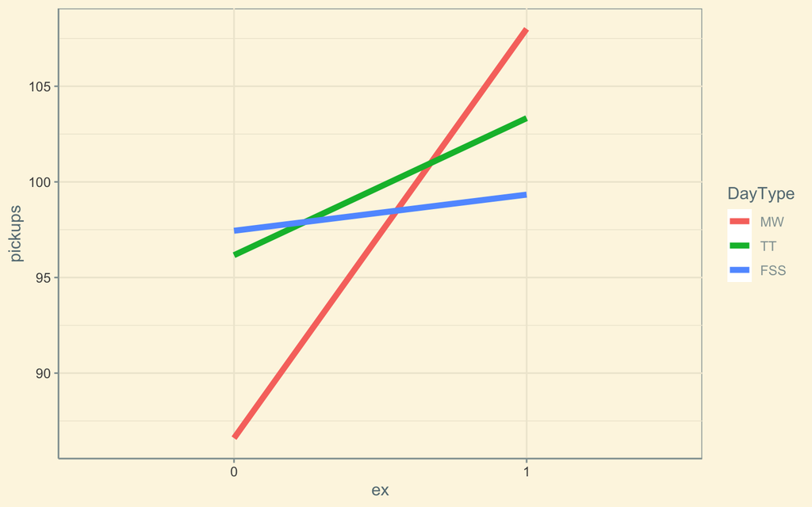

| Observations | 40 (2 missing obs. deleted) |
| --- | --- |
| Dependent variable | pickups |
| Type | OLS linear regression |

| F(5,34) | 1.124 |
| --- | --- |
| R² | 0.142 |
| Adj. R² | 0.016 |

|  | Est. | S.E. | t val. | p |
| --- | --- | --- | --- | --- |
| (Intercept) | 86.600 | 6.926 | 12.503 | 0.000 |
| ex1 | 21.400 | 9.795 | 2.185 | 0.036 |
| DayTypeTT | 9.567 | 9.378 | 1.020 | 0.315 |
| DayTypeFSS | 10.844 | 8.639 | 1.255 | 0.218 |
| ex1:DayTypeTT | -14.233 | 13.263 | -1.073 | 0.291 |
| ex1:DayTypeFSS | -19.511 | 12.217 | -1.597 | 0.120 |

Standard errors: OLS

### Assumptions

Looking at the assumptions of the test, we see that homogeneity of variance does not rigorously hold when the fitted values are small, so any conclusions come with this caveat. Normality of Residuals holds as shown by the qq plot.

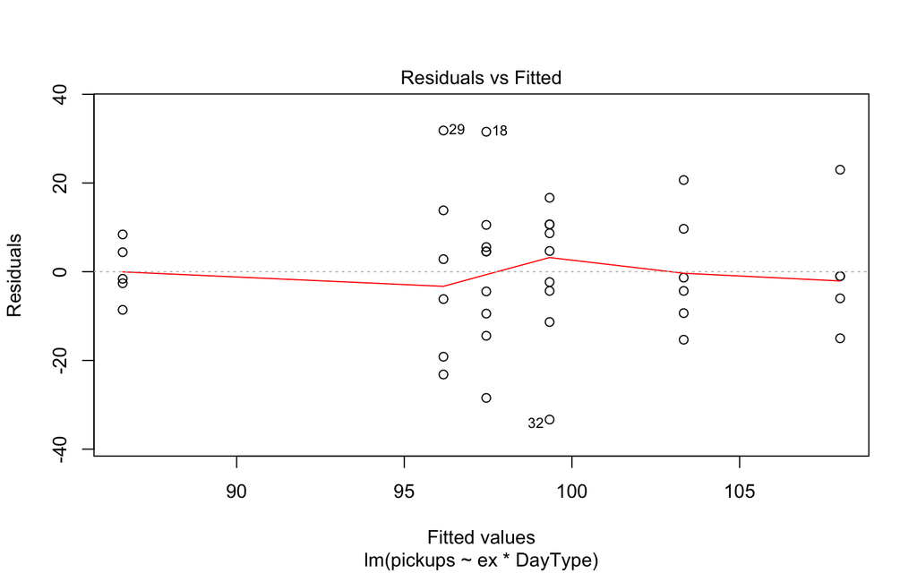

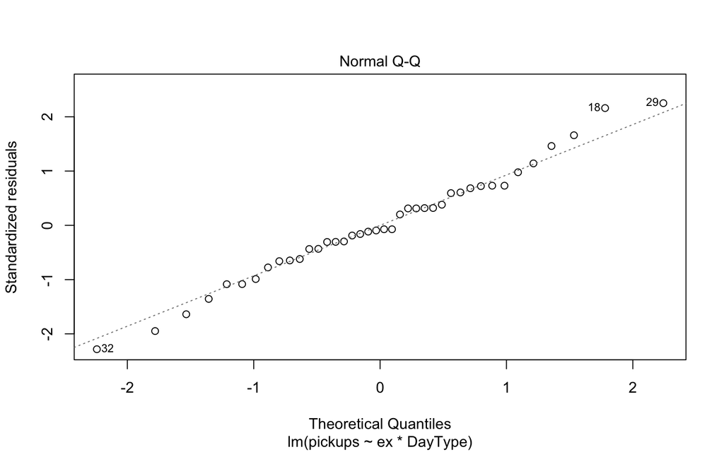

When we look at serial correlation, we see a very slight but not significant effect. Running a regression, we see an estimate of -0.27 per day with a p-value of 0.142.

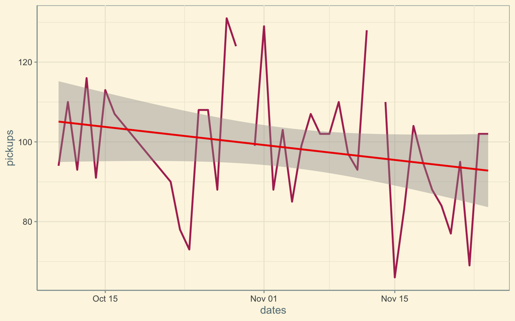

### Results with Serial Correlation

Taking this into account, we see virtually no difference in the output of the regression.

| Observations | 40 (2 missing obs. deleted) |
| --- | --- |
| Dependent variable | pickups |
| Type | OLS linear regression |

| F(6,33) | 1.332 |
| --- | --- |
| R² | 0.195 |
| Adj. R² | 0.049 |

|  | Est. | S.E. | t val. | p |
| --- | --- | --- | --- | --- |
| (Intercept) | 92.853 | 8.020 | 11.578 | 0.000 |
| ex1 | 21.809 | 9.634 | 2.264 | 0.030 |
| DayTypeTT | 9.791 | 9.221 | 1.062 | 0.296 |
| DayTypeFSS | 11.442 | 8.502 | 1.346 | 0.188 |
| day | -0.292 | 0.198 | -1.476 | 0.149 |
| ex1:DayTypeTT | -16.055 | 13.097 | -1.226 | 0.229 |
| ex1:DayTypeFSS | -20.667 | 12.036 | -1.717 | 0.095 |

Standard errors: OLS

### Results with Numeric Response Variable

When we change our output to be the numeric variable length, we see the same story with slightly larger estimate and smaller p_value (Estimate = 24.3, p = 0.0284). This makes sense since exercise is directly predicted by length (exercise is 1 where length is greater than 0).

| Observations | 40 (2 missing obs. deleted) |
| --- | --- |
| Dependent variable | pickups |
| Type | OLS linear regression |

| F(6,33) | 1.418 |
| --- | --- |
| R² | 0.205 |
| Adj. R² | 0.060 |

|  | Est. | S.E. | t val. | p |
| --- | --- | --- | --- | --- |
| (Intercept) | 93.296 | 7.835 | 11.908 | 0.000 |
| length | 24.299 | 10.570 | 2.299 | 0.028 |
| DayTypeTT | 9.087 | 9.076 | 1.001 | 0.324 |
| DayTypeFSS | 13.084 | 8.282 | 1.580 | 0.124 |
| day | -0.305 | 0.199 | -1.534 | 0.135 |
| length:DayTypeTT | -16.910 | 14.270 | -1.185 | 0.244 |
| length:DayTypeFSS | -27.404 | 13.489 | -2.031 | 0.050 |

Standard errors: OLS

We still see a large variation in the effects when looking at the regression by day type.

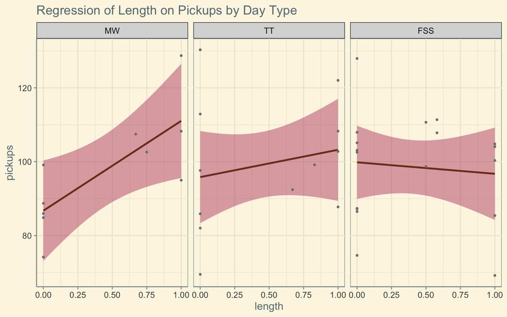

### Further Analyses

#### Interpolation

For the purposes of good interpolation, I also looked at the effect of length of exercise on pickups on only the days I did exercise, but there was no significant effect found (p=0.9).

#### Non-Linearity

We don’t see any significant non-linearity when we look at length with a second order term (p>0.05). Looking at the serial correlation though, we see possible non-linearity.

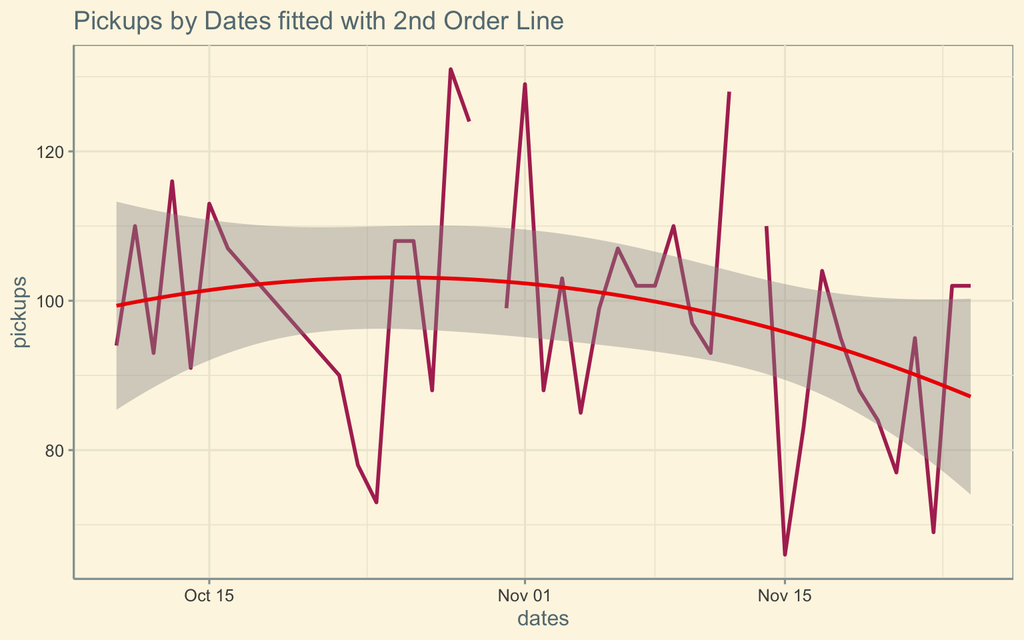

Adding to the model:

| Observations | 40 (2 missing obs. deleted) |
| --- | --- |
| Dependent variable | pickups |
| Type | OLS linear regression |

| F(7,32) | 1.409 |
| --- | --- |
| R² | 0.236 |
| Adj. R² | 0.068 |

|  | Est. | S.E. | t val. | p |
| --- | --- | --- | --- | --- |
| (Intercept) | 85.943 | 9.541 | 9.007 | 0.000 |
| ex1 | 21.242 | 9.543 | 2.226 | 0.033 |
| DayTypeTT | 8.737 | 9.160 | 0.954 | 0.347 |
| DayTypeFSS | 10.884 | 8.424 | 1.292 | 0.206 |
| day | 0.722 | 0.802 | 0.901 | 0.375 |
| I(day^2) | -0.024 | 0.018 | -1.304 | 0.201 |
| ex1:DayTypeTT | -14.829 | 12.994 | -1.141 | 0.262 |
| ex1:DayTypeFSS | -19.646 | 11.936 | -1.646 | 0.110 |

Standard errors: OLS

We see above that this squared term explains a bit more the variance in the data, giving a slightly higher R-squared and adjusted R-squared.

## Discussion

This experiment shows that Griffin Barich will pick up his phone more on days in which he goes to the gym. This is a study with numerous problems detailed below.

### Effect Length and Size

As anyone who has been to the gym can tell you, the effects do not happen right away. While picking up my phone is not the same as losing weight or gaining muscle, it would be naïve to assume that my response variable is an immediate effect. The effect is more pronounced in this experimemnt since I had been going to the gym fewer than one time a week. This is partly modelled by the non-linear serial term, but would need to be remedied further. It might be effective to look at pickups over a whole week where weeks are all assigned different amounts of exercise.

Due to general busyness, I was purposefully vague on the requirements of my exercise. In future studies, it would be beneficial to set specific requirements about time of day and exercise.

While I looked at length at the gym as a possible predictor of pickups, since length did not have much distribution, we cannnot predict from more granular values of length than 30 minutes and cannot predict past 60 minutes because it would be extrapolation.

### Low Variance of Residuals and Measurement Error

As was mentioned above, we saw an issue in the assumption of homogeneity of variance. This could likely be solved by a larger sample size and more careful measurement.

Measurement would be improved if Apple allowed the user to keep historical Screen Time data and export it. With this, we wouldn’t lose the pickups that happen from 11:30 on. There is also merit in changing the way pickups are measured since I was going to sleep around 1 AM and waking up around 9:30 AM. 2 hours of pickups were being misattributed to the following days.

### Internal and External Validity

There are also issues with the internal validity of the experiment. Personally, the responsibilities that I had first semester senior year were unlike any other time in my life. Since I was more busy with extra-curriculars and classes, this is not a representative sample of my life and may not be applicable to other times in my life. If I repeated this experiment next semester or even next year, then I would likely see different results. There were also a few days on which I travelled and so could not use my phone due to me driving. These problems cause me to question the results of the experiment.

The largest problem with this experiment though, is that it is not externally valid. Since the population is only myself, there is no way I can extrapolate this data for any other people. In a future experiment, I would try and get a larger sample population to increase the breadth of the study.

### Conclusions

While this experiment has many issues, the effect is still present. In a future experiment, I would use this study as a baseline to get the effect size and standard deviations to design a new study. The problems of internal and external validity make this hard to draw solid, actionable conclusions off of, but give some idea of the effect during the time of the experiment.

## Appendix

Assignment of Experiment Code:

```r
# Randomly Assigning Days for Exercise:
library(dplyr)
library(randomizr)

dates <- seq(as.Date("2019-10-10"), as.Date("2019-11-25"), 1)
weekdays <- weekdays(dates)

df <- data.frame(dates, weekdays)

df$DayType <- ifelse(df$weekdays %in% c("Monday", "Wednesday"), "MW", ifelse(df$weekdays %in%
    c("Tuesday", "Thursday"), "TT", "FSS"))
"%!in%" <- function(x, y) !(x %in% y)
df <- df %>% filter(dates %!in% seq(as.Date("2019-10-17"), as.Date("2019-10-21"),
    1)) %>% select(-weekdays)


set.seed(1234)
Z <- block_ra(blocks = df$DayType)
blocking_tab <- table(Z, factor(df$DayType, ordered = T, levels = c("MW", "TT", "FSS")))


df$ex <- Z
df$ex[df$dates == "2019-11-15"] <- 1
df$ex[df$dates == "2019-11-16"] <- 0

df$pickups <- NA
```

Data Management Code:

```r
# Reading and Cleaning the Data
library(readr)
data <- read_csv("~/Documents/Documents - Griffin’s MacBook Pro/Senior Year/Fall_2019/Experimental Design/iGotoTheGym/Code:Data/data.csv",
    col_types = cols(DayType = col_factor(levels = c("MW", "TT", "FSS")), X1 = col_integer(),
        dates = col_date(format = "%m/%d/%y"), ex = col_factor(levels = c("0", "1")),
        pickups = col_integer(), tod = col_time(format = "%H:%M")), na = "NA") %>%
    rename(day = X1)

data$length[is.na(data$length)] <- 0
```

Analysis Code:

```r
# Data Analysis
source("~/Documents/Documents - Griffin’s MacBook Pro/Senior Year/Fall_2019/Experimental Design/iGotoTheGym/Code:Data/01_Data_Management.R")
library(jtools)

# Linear Regression with Blocking and Interaction
lm_block <- lm(pickups ~ ex * DayType, data = data)
summary(lm_block)
s_block <- summ(lm_block, digits = 3)

# Check Serial Correlation
lm_serial <- lm(pickups ~ day, data = data)
summary(lm_serial)
s_serial <- summ(lm_serial, digits = 3)

# Serial Correlation with Non-Linearity
lm_serial_2 <- lm(pickups ~ day + I(day^2), data = data)
summary(lm_serial_2)
s_serial <- summ(lm_serial, digits = 3)

# Include Serial Correlation in Model
lm_block_2 <- lm(pickups ~ ex * DayType + day, data = data)
summary(lm_block_2)
s_block_2 <- summ(lm_block_2, digits = 3)

# Include Non-Linear Serial Correlation in Model
lm_block_22 <- lm(pickups ~ ex * DayType + day + I(day^2), data = data)
summary(lm_block_22)
s_block_22 <- summ(lm_block_22, digits = 3)

# Use Length at Gym instead of Binary Indicator
lm_length <- lm(pickups ~ length * DayType + day, data = data)
summary(lm_length)
s_length <- summ(lm_length, digits = 3)

# Look at only Gym Days
lm_length_ex <- lm(pickups ~ length * DayType, data = data[data$ex == 1, ])
summary(lm_length_ex)
s_length_ex <- summ(lm_length_ex)
```

Visualizations Code:

```r
# Visualizations source('~/Documents/Documents - Griffin’s MacBook Pro/Senior
# Year/Fall_2019/Experimental
# Design/iGotoTheGym/Code:Data/00_Assignment_of_Experiment.R')
source("~/Documents/Documents - Griffin’s MacBook Pro/Senior Year/Fall_2019/Experimental Design/iGotoTheGym/Code:Data/01_Data_Management.R")
source("~/Documents/Documents - Griffin’s MacBook Pro/Senior Year/Fall_2019/Experimental Design/iGotoTheGym/Code:Data/02_Data_Analysis.R")

# Load Packages
library(ggplot2)
library(ggthemes)
library(dplyr)
library(visreg)

# Set ggplot Theme
theme_set(theme_solarized())

# Histogram of Pickups
pickup_hist <- ggplot(data) + aes(x = pickups) + geom_histogram(bins = 10)

# Graph of Linear Serial Correlation
ser_cor <- ggplot(data) + aes(x = dates, y = pickups) + geom_line(size = 1L, colour = "maroon") +
    geom_smooth(method = "lm", color = "red2")

# Graph of Quadratic Serial Correlation
ser_cor2 <- ggplot(data) + aes(x = dates, y = pickups) + geom_line(size = 1L, colour = "maroon") +
    geom_smooth(method = "lm", color = "red2", formula = y ~ x + poly(x, 2))

# Visualization of Regression Lines by Day Type
reg <- visreg(fit = lm_length, by = "DayType", xvar = "length", gg = T, line = list(col = "#7A3E20"),
    fill = list(fill = "#B330606B")) + ggtitle("Regression of Length on Pickups by Day Type")

# Interaction Graph
interaction_plot <- ggplot(data[!is.na(data$pickups), ]) + stat_summary(aes(x = ex,
    y = pickups, color = DayType, group = DayType), fun.y = mean, geom = "line",
    size = 2)
```

Data in csv form can be found in the iGototheGym Repository on Github [here](https://github.com/GmanB3398/iGotoTheGym).

2019-12-12